# Cambio Estructural Modelo Ahorro - Ingreso

```r
rm(list=ls())
setwd("c:/Rprograming/CambiosEstructurales-IngresoAhorro")
E1<-read.csv("Datos_Ingreso_Ahorro.csv",header = T,sep = ";",dec = ",")
head(E1) # Muestra algunas filas de los datos con encabezado
```

|  | date | Yt | Xt |
| --- | --- | --- | --- |
| 1 | 1970 | 61.0 | 727.7 |
| 2 | 1971 | 68.6 | 790.2 |
| 3 | 1972 | 63.6 | 855.3 |
| 4 | 1973 | 89.6 | 965.0 |
| 5 | 1974 | 97.6 | 1054.2 |
| 6 | 1975 | 104.4 | 1159.2 |

```r
#install.packages("readxl")

library(readxl) #Carga el paquete
Datos <- read_excel("Datos_Ingreso_Ahorro.xls")
Datos=data.frame(Datos) # Aqui se estable que Tiempo es una hoja de Excel
attach(Datos)
head(Datos)
```

|  | date | Yt | Xt |
| --- | --- | --- | --- |
| 1 | 1970 | 61.0 | 727.7 |
| 2 | 1971 | 68.6 | 790.2 |
| 3 | 1972 | 63.6 | 855.3 |
| 4 | 1973 | 89.6 | 965.0 |
| 5 | 1974 | 97.6 | 1054.2 |
| 6 | 1975 | 104.4 | 1159.2 |

```r
library(normtest)
#install.packages("tinytex")
```

ESTIMACIÓN DEL MODELO RESTRINGIDO

```r
eq1=lm(Yt~Xt)
summary(eq1)
```

```
Call:
lm(formula = Yt ~ Xt)

Residuals:
    Min      1Q  Median      3Q     Max
-62.192 -20.652  -9.459  18.710  67.306

Coefficients:
             Estimate Std. Error t value Pr(>|t|)
(Intercept) 62.689354  12.729576   4.925 5.03e-05 ***
Xt           0.037617   0.004226   8.901 4.54e-09 ***
---
Signif. codes:  0 ‘***’ 0.001 ‘**’ 0.01 ‘*’ 0.05 ‘.’ 0.1 ‘ ’ 1

Residual standard error: 31.05 on 24 degrees of freedom
Multiple R-squared:  0.7675,    Adjusted R-squared:  0.7578
F-statistic: 79.23 on 1 and 24 DF,  p-value: 4.538e-09
```

```r
et=resid(eq1)
summary(et)
```

```
   Min. 1st Qu.  Median    Mean 3rd Qu.    Max.
-62.192 -20.652  -9.459   0.000  18.710  67.306
```

```r
"Suma de cuadrados de los erroes del modelo de la ecuación (1)"
```

```
[1] "Suma de cuadrados de los erroes del modelo de la ecuación (1)"
```

```r
(RSS_R=deviance(eq1))
```

```
[1] 23133.88
```

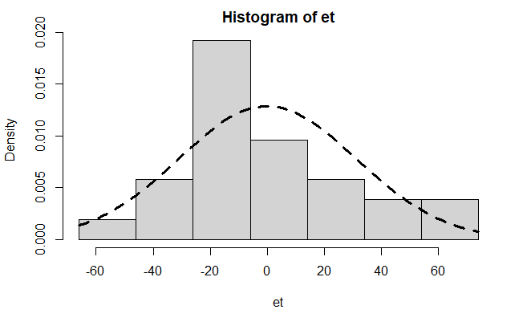

```r
g1_hist=hist(et, seq(-66.0, 74, by=20), prob=TRUE)
curve(dnorm(x,mean = 0,sd=31),col=1,lty=2,lwd=3,add = TRUE)
```

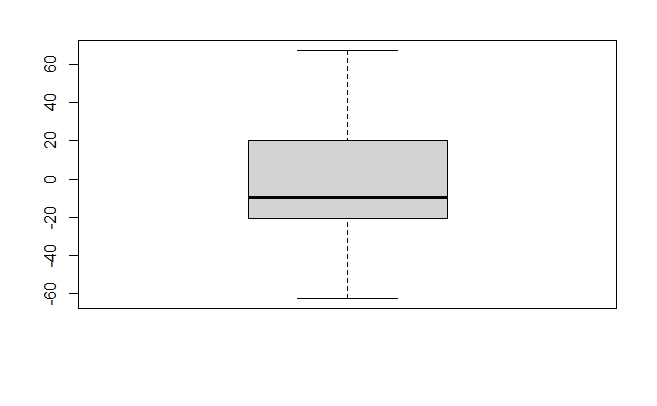

```r
g2_box=boxplot(et)
```

```r
jb.norm.test(et)
```

```
    Jarque-Bera test for normality

data:  et
JB = 1.1732, p-value = 0.387
```

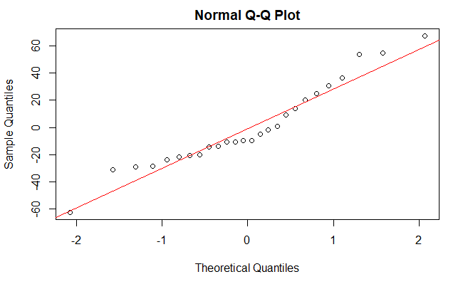

```r
g3_qq <- qqnorm(et,col="black")
qqline(et,col="red")
```

FORMA MATRICIAL DEL MODELO RESTRINGIDO

```r
X=cbind(1,Datos[,3])
y=Datos[,2]
"El vector Xty"
```

```
[1] "El vector Xty"
```

```r
(Xty=t(X)%*%y)
```

```
         [,1]
[1,]     4217
[2,] 13184664
```

```r
"La matriz XtX es:"
```

```
[1] "La matriz XtX es:"
```

```r
(XtX=t(X)%*%X)
```

```
        [,1]        [,2]
[1,]    26.0     68773.6
[2,] 68773.6 235883296.7
```

```r
"la matriz XtX INVERSA ES"
```

```
[1] "la matriz XtX INVERSA ES"
```

```r
(XtX_inv=solve(XtX))
```

```
              [,1]          [,2]
[1,]  1.681089e-01 -4.901345e-05
[2,] -4.901345e-05  1.852964e-08
```

```r
"EL ESTIMADOR b DE OLS ES"
```

```
[1] "EL ESTIMADOR b DE OLS ES"
```

```r
(b=XtX_inv%*%Xty)
```

```
            [,1]
[1,] 62.68935410
[2,]  0.03761729
```

```r
"EL yt_est ES"
```

```
[1] "EL yt_est ES"
```

```r
ye=X%*%b
"LOS ERROES DE ESTIMACIÓN SON"
```

```
[1] "LOS ERROES DE ESTIMACIÓN SON"
```

```r
et=y-ye
"SUMAS DE CUADRADOS"
```

```
[1] "SUMAS DE CUADRADOS"
```

```r
"SUMAS DE CUADRADOS TOTALES"
```

```
[1] "SUMAS DE CUADRADOS TOTALES"
```

```r
(TSS=sum((y-mean(y))^2))
```

```
[1] 99501.32
```

```r
(TSS_A=t(y)%*%y-26*mean(y)^2)
```

```
         [,1]
[1,] 99501.32
```

```r
"SUMA DE CUAADRADOS EXPLICADA"
```

```
[1] "SUMA DE CUAADRADOS EXPLICADA"
```

```r
(ESS=t(b)%*%XtX%*%b-26*mean(y)^2)
```

```
         [,1]
[1,] 76367.44
```

```r
"SUMA DE CUADRADOS DE LOS ERROES"
```

```
[1] "SUMA DE CUADRADOS DE LOS ERROES"
```

```r
(RSS=t(et)%*%et)
```

```
         [,1]
[1,] 23133.88
```

ESTIMACIÓN DEL MODELO NO RESTRINGIDO CON EL COMNADO lm, PARA ELLO SE DEFINESN LAS VARIABLES D1, D2, x1t y x2t. SE ESTIMA EL MODELO POR SUBMUESTRAS

```r
"1. MODELO CON LAS PRIMERAS 15 OBSERVACIONES DESDE 1970 HASTA 1984"
```

```
[1] "1. MODELO CON LAS PRIMERAS 15 OBSERVACIONES DESDE 1970 HASTA 1984"
```

```r
"LA MATRIZ DE DATOS X1"
```

```
[1] "LA MATRIZ DE DATOS X1"
```

```r
X1=cbind(1,Datos[1:15,3])
y1=Datos[1:15,2]
x1t=cbind(X1[1:15,2])
y1t=y1[1:15]
On1=matrix(nrow=15,ncol = 1,0)
in1=matrix(nrow=15,ncol = 1,1)
"Estimación del modelo 1"
```

```
[1] "Estimación del modelo 1"
```

```r
eq1_m1=lm(y1t~x1t)
summary(eq1_m1)
```

```
Call:
lm(formula = y1t ~ x1t)

Residuals:
    Min      1Q  Median      3Q     Max
-34.248  -9.451   3.276  11.059  23.134

Coefficients:
             Estimate Std. Error t value Pr(>|t|)
(Intercept)  3.318321  10.710690    0.31    0.762
x1t          0.078469   0.006327   12.40 1.41e-08 ***
---
Signif. codes:  0 ‘***’ 0.001 ‘**’ 0.01 ‘*’ 0.05 ‘.’ 0.1 ‘ ’ 1

Residual standard error: 16 on 13 degrees of freedom
Multiple R-squared:  0.9221,    Adjusted R-squared:  0.9161
F-statistic: 153.8 on 1 and 13 DF,  p-value: 1.406e-08
```

```r
"Suma de cuadrados de los erroes del modelo 1: 1970 - 1984"
```

```
[1] "Suma de cuadrados de los erroes del modelo 1: 1970 - 1984"
```

```r
RSS_1=deviance(eq1_m1)
RSS_1
```

```
[1] 3327.055
```

```r
"ESTIMACIÓN EN FORMA MATRICIAL"
```

```
[1] "ESTIMACIÓN EN FORMA MATRICIAL"
```

```r
"La matriz X1tX1 es"
```

```
[1] "La matriz X1tX1 es"
```

```r
(X1tX1=t(X1)%*%X1)
```

```
        [,1]       [,2]
[1,]    15.0    23428.7
[2,] 23428.7 42986923.2
```

```r
"La matriz X1tX1 inversa es"
```

```
[1] "La matriz X1tX1 inversa es"
```

```r
(X1tX1_inv=solve(X1tX1))
```

```
              [,1]          [,2]
[1,]  0.4482480056 -2.443038e-04
[2,] -0.0002443038  1.564132e-07
```

```r
"El vector X1ty1 es"
```

```
[1] "El vector X1ty1 es"
```

```r
(X1ty1=t(X1)%*%y1)
```

```
          [,1]
[1,]    1888.2
[2,] 3450882.1
```

```r
"El estimador OLS con la primera muestra es:"
```

```
[1] "El estimador OLS con la primera muestra es:"
```

```r
(b1=X1tX1_inv%*%X1ty1)
```

```
           [,1]
[1,] 3.31832121
[2,] 0.07846894
```

```r
"SUMAS DE CUADRADOS DEL MODELO 1"
```

```
[1] "SUMAS DE CUADRADOS DEL MODELO 1"
```

```r
et1=y1-X1%*%b1
"El RSS1 es"
```

```
[1] "El RSS1 es"
```

```r
(RSS1=t(et1)%*%et1)
```

```
         [,1]
[1,] 3327.055
```

```r
"El ESS1"
```

```
[1] "El ESS1"
```

```r
(ESS1=t(b1)%*%X1tX1%*%b1-15*mean(y1)^2)
```

```
         [,1]
[1,] 39366.09
```

```r
"El TSS1 es"
```

```
[1] "El TSS1 es"
```

```r
(TSS1=t(y1)%*%y1-15*mean(y1)^2)
```

```
         [,1]
[1,] 42693.14
```

```r
"El TSS1 prueba es"
```

```
[1] "El TSS1 prueba es"
```

```r
(TSS1p=ESS1+RSS1)
```

```
         [,1]
[1,] 42693.14
```

ESTIMACIÓN DEL MODELO CON LAS ULTIMAS n2 = 11 OBSERVACIONES

```r
"2. MODELO CON LAS ULTIMAS 11 OBSERVACIONES DESDE 1985 HASTA 1995"
```

```
[1] "2. MODELO CON LAS ULTIMAS 11 OBSERVACIONES DESDE 1985 HASTA 1995"
```

```r
"LA MATRIZ DE DATOS X2"
```

```
[1] "LA MATRIZ DE DATOS X2"
```

```r
X2=cbind(1,Datos[16:26,3])
"EL VECTOR y2"
```

```
[1] "EL VECTOR y2"
```

```r
y2=Datos[16:26,2]
x2t=cbind(X2[1:11,2])
y2t=y2[1:11]
"El vector 0 de tamanño n2 es"
```

```
[1] "El vector 0 de tamanño n2 es"
```

```r
On2=matrix(nrow=11,ncol = 1,0)
"el vector in2 es"
```

```
[1] "el vector in2 es"
```

```r
in2=matrix(nrow=11,ncol = 1,1)
"Estimación del modelo 2"
```

```
[1] "Estimación del modelo 2"
```

```r
eq1_m2=lm(y2t~x2t)
summary(eq1_m2)
```

```
Call:
lm(formula = y2t ~ x2t)

Residuals:
    Min      1Q  Median      3Q     Max
-42.466 -15.541  -4.007  15.164  49.877

Coefficients:
             Estimate Std. Error t value Pr(>|t|)
(Intercept) 119.32551   47.98623   2.487   0.0346 *
x2t           0.02241    0.01146   1.956   0.0822 .
---
Signif. codes:  0 ‘***’ 0.001 ‘**’ 0.01 ‘*’ 0.05 ‘.’ 0.1 ‘ ’ 1

Residual standard error: 28.01 on 9 degrees of freedom
Multiple R-squared:  0.2982,    Adjusted R-squared:  0.2203
F-statistic: 3.825 on 1 and 9 DF,  p-value: 0.08221
```

```r
"Suma de cuadrados de los errroes del modelo 2: 1985 - 1995"
```

```
[1] "Suma de cuadrados de los errroes del modelo 2: 1985 - 1995"
```

```r
RSS_2=deviance(eq1_m2)
RSS_2
```

```
[1] 7058.593
```

```r
"ESTIMACIÓN EN FORMA MATRICIAL"
```

```
[1] "ESTIMACIÓN EN FORMA MATRICIAL"
```

```r
"La matriz X2tX2 es"
```

```
[1] "La matriz X2tX2 es"
```

```r
(X2tX2=t(X2)%*%X2)
```

```
        [,1]        [,2]
[1,]    11.0     45344.9
[2,] 45344.9 192896373.4
```

```r
"La matriz X2tX2 inversa es"
```

```
[1] "La matriz X2tX2 inversa es"
```

```r
(X2tX2_inv=solve(X2tX2))
```

```
              [,1]          [,2]
[1,]  2.9360110708 -6.901795e-04
[2,] -0.0006901795  1.674273e-07
```

```r
"El vector X2ty2 es"
```

```
[1] "El vector X2ty2 es"
```

```r
(X2ty2=t(X2)%*%y2)
```

```
          [,1]
[1,]    2328.8
[2,] 9733782.0
```

```r
"El estimador OLS con la segunda muestra es:"
```

```
[1] "El estimador OLS con la segunda muestra es:"
```

```r
(b2=X2tX2_inv%*%X2ty2)
```

```
             [,1]
[1,] 119.32550769
[2,]   0.02241089
```

```r
"SUMAS DE CUADRADOS DEL MODELO 2"
```

```
[1] "SUMAS DE CUADRADOS DEL MODELO 2"
```

```r
et2=y2-X2%*%b2
"El RSS2 es"
```

```
[1] "El RSS2 es"
```

```r
(RSS2=t(et2)%*%et2)
```

```
         [,1]
[1,] 7058.593
```

```r
"El ESS2"
```

```
[1] "El ESS2"
```

```r
(ESS2=t(b2)%*%X2tX2%*%b2-11*mean(y2)^2)
```

```
         [,1]
[1,] 2999.796
```

```r
"El TSS2 es"
```

```
[1] "El TSS2 es"
```

```r
(TSS2=t(y2)%*%y2-11*mean(y2)^2)
```

```
         [,1]
[1,] 10058.39
```

```r
"El TSS2 prueba es"
```

```
[1] "El TSS2 prueba es"
```

```r
(TSS2p=ESS2+RSS2)
```

```
         [,1]
[1,] 10058.39
```

DEFINICIÓN DE LAS VARIABLES PARA EL MODELO NO RESTRINGIDO

```r
"Variables D1 y D2"
```

```
[1] "Variables D1 y D2"
```

```r
"La variable D1"
```

```
[1] "La variable D1"
```

```r
d1=rbind(in1,On2)
d1
```

```
      [,1]
 [1,]    1
 [2,]    1
 [3,]    1
 [4,]    1
 [5,]    1
 [6,]    1
 [7,]    1
 [8,]    1
 [9,]    1
[10,]    1
[11,]    1
[12,]    1
[13,]    1
[14,]    1
[15,]    1
[16,]    0
[17,]    0
[18,]    0
[19,]    0
[20,]    0
[21,]    0
[22,]    0
[23,]    0
[24,]    0
[25,]    0
[26,]    0
```

```r
"La variable D2 es"
```

```
[1] "La variable D2 es"
```

```r
d2=rbind(On1,in2)
d2
```

```
      [,1]
 [1,]    0
 [2,]    0
 [3,]    0
 [4,]    0
 [5,]    0
 [6,]    0
 [7,]    0
 [8,]    0
 [9,]    0
[10,]    0
[11,]    0
[12,]    0
[13,]    0
[14,]    0
[15,]    0
[16,]    1
[17,]    1
[18,]    1
[19,]    1
[20,]    1
[21,]    1
[22,]    1
[23,]    1
[24,]    1
[25,]    1
[26,]    1
```

```r
"La variable Xt1 es"
```

```
[1] "La variable Xt1 es"
```

```r
Xt1=rbind(x1t,On2)
"La variable Xt2 es"
```

```
[1] "La variable Xt2 es"
```

```r
Xt2=rbind(On1,x2t)
"Modelo no restringido estimado"
```

```
[1] "Modelo no restringido estimado"
```

```r
eq1_mnr=lm(Yt~d1+Xt1+d2+Xt2-1)
summary(eq1_mnr)
```

```
Call:
lm(formula = Yt ~ d1 + Xt1 + d2 + Xt2 - 1)

Residuals:
    Min      1Q  Median      3Q     Max
-42.466 -12.226   1.928  11.352  49.877

Coefficients:
     Estimate Std. Error t value Pr(>|t|)
d1  3.318e+00  1.455e+01   0.228  0.82166
Xt1 7.847e-02  8.593e-03   9.132 6.14e-09 ***
d2  1.193e+02  3.723e+01   3.205  0.00408 **
Xt2 2.241e-02  8.890e-03   2.521  0.01946 *
---
Signif. codes:  0 ‘***’ 0.001 ‘**’ 0.01 ‘*’ 0.05 ‘.’ 0.1 ‘ ’ 1

Residual standard error: 21.73 on 22 degrees of freedom
Multiple R-squared:  0.9867,    Adjusted R-squared:  0.9843
F-statistic: 409.4 on 4 and 22 DF,  p-value: < 2.2e-16
```

```r
"La suma de cuadrados de los erroes del Modelo no Restringido es"
```

```
[1] "La suma de cuadrados de los erroes del Modelo no Restringido es"
```

```r
(RSS_NR=deviance(eq1_mnr))
```

```
[1] 10385.65
```

```r
"Prueba de la ecuación (16)"
```

```
[1] "Prueba de la ecuación (16)"
```

```r
(RSS_NR_16=RSS_1+RSS_2)
```

```
[1] 10385.65
```

FORMA MATRICIAL DEL MODELO NO RESTRINGIDO

```r
"CONSTRUCCIÓN DE LA MATRIX XNR"
```

```
[1] "CONSTRUCCIÓN DE LA MATRIX XNR"
```

```r
O15=matrix(nrow=15,ncol=2,0)
O11=matrix(nrow=11,ncol=2,0)
A1=rbind(X1,O11)
A2=rbind(O15,X2)
"MATRIZ XNR"
```

```
[1] "MATRIZ XNR"
```

```r
(XNR=cbind(A1,A2))
```

```
      [,1]   [,2] [,3]   [,4]
 [1,]    1  727.7    0    0.0
 [2,]    1  790.2    0    0.0
 [3,]    1  855.3    0    0.0
 [4,]    1  965.0    0    0.0
 [5,]    1 1054.2    0    0.0
 [6,]    1 1159.2    0    0.0
 [7,]    1 1273.0    0    0.0
 [8,]    1 1401.4    0    0.0
 [9,]    1 1580.1    0    0.0
[10,]    1 1769.5    0    0.0
[11,]    1 1973.2    0    0.0
[12,]    1 2200.2    0    0.0
[13,]    1 2347.3    0    0.0
[14,]    1 2522.4    0    0.0
[15,]    1 2810.0    0    0.0
[16,]    0    0.0    1 3002.0
[17,]    0    0.0    1 3187.6
[18,]    0    0.0    1 3363.1
[19,]    0    0.0    1 3640.8
[20,]    0    0.0    1 3894.5
[21,]    0    0.0    1 4166.8
[22,]    0    0.0    1 4343.7
[23,]    0    0.0    1 4613.7
[24,]    0    0.0    1 4790.2
[25,]    0    0.0    1 5021.7
[26,]    0    0.0    1 5320.8
```

EATIMADOR OLS DEL MODELO NO RESTRINGIDO EN FORMA MATRICIAL:

```r
"LA MATRIZ XNRtXNR"
```

```
[1] "LA MATRIZ XNRtXNR"
```

```r
(XNRtXNR=t(XNR)%*%XNR)
```

```
        [,1]       [,2]    [,3]        [,4]
[1,]    15.0    23428.7     0.0         0.0
[2,] 23428.7 42986923.2     0.0         0.0
[3,]     0.0        0.0    11.0     45344.9
[4,]     0.0        0.0 45344.9 192896373.4
```

```r
"LA MATRIZ XNRtXNR inversa"
```

```
[1] "LA MATRIZ XNRtXNR inversa"
```

```r
(XNRtXNR_inv=solve(XNRtXNR))
```

```
              [,1]          [,2]          [,3]          [,4]
[1,]  0.4482480056 -2.443038e-04  0.0000000000  0.000000e+00
[2,] -0.0002443038  1.564132e-07  0.0000000000  0.000000e+00
[3,]  0.0000000000  0.000000e+00  2.9360110708 -6.901795e-04
[4,]  0.0000000000  0.000000e+00 -0.0006901795  1.674273e-07
```

```r
"EL VECTOR XNRty"
```

```
[1] "EL VECTOR XNRty"
```

```r
(XNRty=t(XNR)%*%y)
```

```
          [,1]
[1,]    1888.2
[2,] 3450882.1
[3,]    2328.8
[4,] 9733782.0
```

```r
"EL ESTIMADOR OLS DEL MODELO NO RESTRINGIDO ES"
```

```
[1] "EL ESTIMADOR OLS DEL MODELO NO RESTRINGIDO ES"
```

```r
(bnr=XNRtXNR_inv%*%XNRty)
```

```
             [,1]
[1,]   3.31832121
[2,]   0.07846894
[3,] 119.32550769
[4,]   0.02241089
```

SUMAS DE CUADRADOS EN EL MODELO NO RESTRINGIDO

```r
etnr=y-XNR%*%bnr
"SUMA DE CUADRADOS DE ERRROES NR"
```

```
[1] "SUMA DE CUADRADOS DE ERRROES NR"
```

```r
(RSS_NR_MAT=t(etnr)%*%etnr)
```

```
         [,1]
[1,] 10385.65
```

```r
"SUMA DE CUADRADOS EXPLICADA NR"
```

```
[1] "SUMA DE CUADRADOS EXPLICADA NR"
```

```r
(ESS_NR=(t(bnr)%*%XNRtXNR%*%bnr)[1:1]-26*mean(y)^2)
```

```
[1] 89115.67
```

```r
"LA SUMA TOTAL CUADRADOS NR ES"
```

```
[1] "LA SUMA TOTAL CUADRADOS NR ES"
```

```r
(TSS_NR=(t(y)%*%y)[1:1]-26*mean(y)^2)
```

```
[1] 99501.32
```

```r
"PRUEBA DE SUMAS DE CUADRADOS EN EL MODELO NR"
```

```
[1] "PRUEBA DE SUMAS DE CUADRADOS EN EL MODELO NR"
```

```r
(TSS_NR_PRUEBA=ESS_NR+RSS_NR)
```

```
[1] 99501.32
```

PRUEBA DE CAMMBIO ESTRUCTUTURAL:

```r
"ESTADÍSTICA F DE LA ECUAIOÓN (20)"
```

```
[1] "ESTADÍSTICA F DE LA ECUAIOÓN (20)"
```

```r
"EL VALOR CALCULADO DE LA ESTADÍSTICA ES"
```

```
[1] "EL VALOR CALCULADO DE LA ESTADÍSTICA ES"
```

```r
(FC_20=(((RSS_R-RSS_NR)/2)/(RSS_NR/22)))
```

```
[1] 13.50234
```

```r
"EL P VALOR ES"
```

```
[1] "EL P VALOR ES"
```

```r
(PV_F_20=pf(FC_20,2,22,lower.tail = F))
```

```
[1] 0.0001492921
```

ESTADÍSTICA F DE LA ECUACIÓN (18):

```r
"DEFINImOS LA MATRIZ R"
```

```
[1] "DEFINImOS LA MATRIZ R"
```

```r
"INICIALMENTE MATRIZ IDENTIDAD DE ORDEN 2"
```

```
[1] "INICIALMENTE MATRIZ IDENTIDAD DE ORDEN 2"
```

```r
I2=diag(2)
"la matiz R es"
```

```
[1] "la matiz R es"
```

```r
R=cbind(I2,-I2)
R
```

```
     [,1] [,2] [,3] [,4]
[1,]    1    0   -1    0
[2,]    0    1    0   -1
```

```r
"el vector r es"
```

```
[1] "el vector r es"
```

```r
vr=matrix(nrow = 2,ncol = 1,0)
vr
```

```
     [,1]
[1,]    0
[2,]    0
```

```r
"ESTADÍSTICA F DE LA ECUACIÓN (18)"
```

```
[1] "ESTADÍSTICA F DE LA ECUACIÓN (18)"
```

```r
"EL VALOR CALCULADO DE LA ESTADÍSTICA DE LA ECUACIÓN (18) ES"
```

```
[1] "EL VALOR CALCULADO DE LA ESTADÍSTICA DE LA ECUACIÓN (18) ES"
```

```r
FC_18=((t(R%*%bnr-vr)%*%solve(R%*%XNRtXNR_inv%*%t(R))%*%(R%*%bnr-vr))[1:1]/2)/(RSS_NR/22)
FC_18
```

```
[1] 13.50234
```

ESTADÍSTCA F DE LA ECUACIÓN (19)

```r
"LA ESTADÍSTICA F DE LA ECUACIÓN (19) ES"
```

```
[1] "LA ESTADÍSTICA F DE LA ECUACIÓN (19) ES"
```

```r
FC_19=((t(b1-b2)%*%solve(X1tX1_inv+X2tX2_inv)%*%(b1-b2))[1:1]/2)/(RSS_NR/22)
FC_19
```

```
[1] 13.50234
```

COMPARACIÓN DE LAS ESTADÍSTICAS ECUACIONES (18), (19) Y (20)

```r
"TABLA PARA COMPARAR LOS VALORES"
```

```
[1] "TABLA PARA COMPARAR LOS VALORES"
```

```r
col1=c("ESTADÍSTICA F","ECUACIÓN (18)","ECUACIÓN (19)","ECUACIÓN (20)", "P VALOR")
col2=c("VALOR", FC_18, FC_19, FC_20, PV_F_20)
(TABLA_ESTAD_F=cbind(col1,col2))
```

```
     col1            col2
[1,] "ESTADÍSTICA F" "VALOR"
[2,] "ECUACIÓN (18)" "13.5023374334102"
[3,] "ECUACIÓN (19)" "13.5023374334102"
[4,] "ECUACIÓN (20)" "13.5023374334104"
[5,] "P VALOR"       "0.000149292109898194"
```

E4 “CAMBIO ESTRUCTURAL CON VARIABLES DUMMY” ESTIMACIÓN DEL MODELO CON VARIAVLES DUMMY

```r
eq1_mnr_d=lm(y~d2+Xt+d2*Xt)
summary(eq1_mnr_d)
```

```
Call:
lm(formula = y ~ d2 + Xt + d2 * Xt)

Residuals:
    Min      1Q  Median      3Q     Max
-42.466 -12.226   1.928  11.352  49.877

Coefficients:
              Estimate Std. Error t value Pr(>|t|)
(Intercept)   3.318321  14.546705   0.228 0.821664
d2          116.007186  39.970285   2.902 0.008261 **
Xt            0.078469   0.008593   9.132 6.14e-09 ***
d2:Xt        -0.056058   0.012364  -4.534 0.000164 ***
---
Signif. codes:  0 ‘***’ 0.001 ‘**’ 0.01 ‘*’ 0.05 ‘.’ 0.1 ‘ ’ 1

Residual standard error: 21.73 on 22 degrees of freedom
Multiple R-squared:  0.8956,    Adjusted R-squared:  0.8814
F-statistic: 62.92 on 3 and 22 DF,  p-value: 5.893e-11
```

```r
summary(et)
```

```
       V1
 Min.   :-62.192
 1st Qu.:-20.652
 Median : -9.459
 Mean   :  0.000
 3rd Qu.: 18.710
 Max.   : 67.306
```

```r
"Suma de cuadrados de los errores del modelo no restringido con DUMMY"
```

```
[1] "Suma de cuadrados de los errores del modelo no restringido con DUMMY"
```

```r
(RSS_NRD=deviance(eq1_mnr_d))
```

```
[1] 10385.65
```

```r
"prueba de cambio estructural con variables Dymmy"
```

```
[1] "prueba de cambio estructural con variables Dymmy"
```

```r
"La estadística F de la ecuación (22) calculada"
```

```
[1] "La estadística F de la ecuación (22) calculada"
```

```r
(FC_22=((RSS_R-RSS_NRD)/2)/(RSS_NRD/22))
```

```
[1] 13.50234
```

```r
"verificación de coeficientes"
```

```
[1] "verificación de coeficientes"
```

```r
bnrd=cbind(coef(eq1_mnr_d))
bnrd
```

```
                    [,1]
(Intercept)   3.31832121
d2          116.00718648
Xt            0.07846894
d2:Xt        -0.05605805
```

```r
b11nrd=bnrd[1]
delta1=bnrd[2]
b12nrd=b11nrd+delta1
b21nrd=bnrd[3]
delta2=bnrd[4]
b22nrd=b21nrd+delta2
"verificación de coeficientes"
```

```
[1] "verificación de coeficientes"
```

```r
coef1=c("Coef.MNRD","b1nrd","delta1","b1+delta1","b2nrd","delta2","b2+delta2")
coef1
```

```
[1] "Coef.MNRD" "b1nrd"     "delta1"    "b1+delta1" "b2nrd"     "delta2"
[7] "b2+delta2"
```

```r
coef2=c("valor",b11nrd,delta1,b12nrd,b21nrd,delta2,b22nrd)
coef3=c("Coef.MNR","b1m1","______","b1m2","b2m1","________","b2m2")
coef4=c("Valor",bnr[1],"______",bnr[3],bnr[2],"________",bnr[4])
t_coef=cbind(coef1,coef2,coef3,coef4)
t_coef
```

```
     coef1       coef2                 coef3      coef4
[1,] "Coef.MNRD" "valor"               "Coef.MNR" "Valor"
[2,] "b1nrd"     "3.31832120521647"    "b1m1"     "3.31832120521676"
[3,] "delta1"    "116.007186483373"    "______"   "______"
[4,] "b1+delta1" "119.32550768859"     "b1m2"     "119.325507688592"
[5,] "b2nrd"     "0.0784689368988357"  "b2m1"     "0.0784689368988357"
[6,] "delta2"    "-0.0560580502186245" "________" "________"
[7,] "b2+delta2" "0.0224108866802112"  "b2m2"     "0.0224108866802111"
```

E5 “PRUEBA PARA CAMBIO EN EL INTERCEPTO O EN LA PENDIENTE” CAMBIO SOLO EN EL INTERCEPTO

```r
"MODELO NO RESTRINGIDO PARA PROBAR QUE SÓLO HAY CAMBIO EN EL INTERCEPTO"
```

```
[1] "MODELO NO RESTRINGIDO PARA PROBAR QUE SÓLO HAY CAMBIO EN EL INTERCEPTO"
```

```r
eq1_m1_inter=lm(Yt~d1+d2+Xt-1)
summary(eq1_m1_inter)
```

```
Call:
lm(formula = Yt ~ d1 + d2 + Xt - 1)

Residuals:
   Min     1Q Median     3Q    Max
-68.53 -16.87  -5.45  21.18  52.06

Coefficients:
    Estimate Std. Error t value Pr(>|t|)
d1 45.608261  15.183735   3.004  0.00633 **
d2 -0.147267  35.772650  -0.004  0.99675
Xt  0.051393   0.008404   6.115 3.08e-06 ***
---
Signif. codes:  0 ‘***’ 0.001 ‘**’ 0.01 ‘*’ 0.05 ‘.’ 0.1 ‘ ’ 1

Residual standard error: 29.55 on 23 degrees of freedom
Multiple R-squared:  0.9744,    Adjusted R-squared:  0.971
F-statistic: 291.3 on 3 and 23 DF,  p-value: < 2.2e-16
```

```r
RSS_NR_INTER=deviance(eq1_m1_inter)
"La suma de cuadrados de los errores del modelo no restringido para cambio en el intercepto es"
```

```
[1] "La suma de cuadrados de los errores del modelo no restringido para cambio en el intercepto es"
```

```r
RSS_NR_INTER
```

```
[1] 20089.51
```

ESTADÍSTICA DE PRUEBA DE LA ECUACIÓN (26).. CAMBIO SOLO EN EL INTERCEPTO

```r
"ESTADÍSTICA F DE LA ECUACIÓN (26)"
```

```
[1] "ESTADÍSTICA F DE LA ECUACIÓN (26)"
```

```r
FC_26=((RSS_R-RSS_NR_INTER)/1)/(RSS_NR_INTER/23)
"el valor calculado de la estadística F de la ecuación (26) es"
```

```
[1] "el valor calculado de la estadística F de la ecuación (26) es"
```

```r
FC_26
```

```
[1] 3.485415
```

```r
PV_F_E26=pf(FC_26,1,23,lower.tail = F)
"El valor p de la prueba para cambio solo en el intercepto es"
```

```
[1] "El valor p de la prueba para cambio solo en el intercepto es"
```

```r
PV_F_E26
```

```
[1] 0.07471092
```

PRUEBA PARA CAMBIO EN LA PENDIENTE CON INTERCEPTO COMÚN

```r
"MODELO NO RESTRINGIDO PARA PROBAR QUE SÓLO HAY CAMBIO EN LA PENDIENTE"
```

```
[1] "MODELO NO RESTRINGIDO PARA PROBAR QUE SÓLO HAY CAMBIO EN LA PENDIENTE"
```

```r
eq1_m1_pend=lm(Yt~Xt1+Xt2)
summary(eq1_m1_pend)
```

```
Call:
lm(formula = Yt ~ Xt1 + Xt2)

Residuals:
    Min      1Q  Median      3Q     Max
-60.629 -14.035  -3.582  16.294  49.217

Coefficients:
             Estimate Std. Error t value Pr(>|t|)
(Intercept) 18.683572  15.583059   1.199    0.243
Xt1          0.070095   0.009309   7.530 1.19e-07 ***
Xt2          0.046069   0.004081  11.288 7.41e-11 ***
---
Signif. codes:  0 ‘***’ 0.001 ‘**’ 0.01 ‘*’ 0.05 ‘.’ 0.1 ‘ ’ 1

Residual standard error: 24.99 on 23 degrees of freedom
Multiple R-squared:  0.8557,    Adjusted R-squared:  0.8431
F-statistic: 68.17 on 2 and 23 DF,  p-value: 2.153e-10
```

```r
RSS_NR_P=deviance(eq1_m1_pend)
"La suma de cuadrados de los errores del modelo no restringido para cambio en la pendiente es"
```

```
[1] "La suma de cuadrados de los errores del modelo no restringido para cambio en la pendiente es"
```

```r
RSS_NR_P
```

```
[1] 14362.19
```

ESTADÍSTICA F DE LA ECUACIÓN (30): CAMBIO SOLO EN LA PENDIENTE

```r
"ESTADÍSTICA F DE LA ECUACIÓN (30)"
```

```
[1] "ESTADÍSTICA F DE LA ECUACIÓN (30)"
```

```r
FC_30=((RSS_R-RSS_NR_P)/1)/(RSS_NR_P/23)
"el valor calculado de la estadística F de la ecuación (30) es"
```

```
[1] "el valor calculado de la estadística F de la ecuación (30) es"
```

```r
FC_30
```

```
[1] 14.0472
```

```r
PV_F_E30=pf(FC_30,1,23,lower.tail = F)
"El valor p de la prueba para cambio solo en la pendiente"
```

```
[1] "El valor p de la prueba para cambio solo en la pendiente"
```

```r
PV_F_E30
```

```
[1] 0.001049693
```

SERIES DE TIEMPO

```r
sxt=ts(Xt,start = c(1970),end = c(1995),frequency = 1)
sxt
```

```
Time Series:
Start = 1970
End = 1995
Frequency = 1
 [1]  727.7  790.2  855.3  965.0 1054.2 1159.2 1273.0 1401.4 1580.1 1769.5
[11] 1973.2 2200.2 2347.3 2522.4 2810.0 3002.0 3187.6 3363.1 3640.8 3894.5
[21] 4166.8 4343.7 4613.7 4790.2 5021.7 5320.8
```

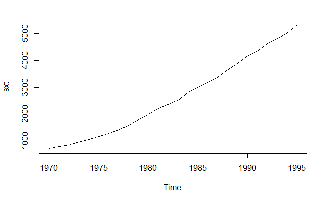

```r
plot(sxt)
```